# Python 的五十道練習：資料分析的敲門磚

> 簡介

[數聚點](https://www.datainpoint.com) | 郭耀仁 yaojenkuo@datainpoint.com

## 給同學的課前心理建設

- 雖然我們可能從很多資訊來源聽到 Python 簡單易學，但是對於完全沒有接觸過程式設計的初學者而言，要在第一次學習 Python 就能上手還是有難度的。
- 有的時候同樣一個主題，可能要多聽幾次，甚至聽不同人講述，才能突然茅塞頓開。
- 覺得累了的時候，休息個幾天、轉換心情再回來，學習效果會更好。

## 現代資料科學：以程式設計進行資料分析

[figure not shown]

來源：[R for Data Science](https://r4ds.had.co.nz)

## 有很多程式語言可以做到前述六項的應用，為什麼選 Python

- R
- Matlab
- Julia
- SAS
- Scala
- ...etc.

## 選擇最多人使用的程式語言

- [2022 Kaggle ML & DS Survey](https://www.kaggle.com/c/kaggle-survey-2022)
- [Stack Overflow Trends](https://insights.stackoverflow.com/trends?tags=python%2Cr%2Cmatlab%2Cjulia%2Csas%2Cscala)

## [2022 Kaggle ML & DS Survey](https://www.kaggle.com/c/kaggle-survey-2022) 中的問題

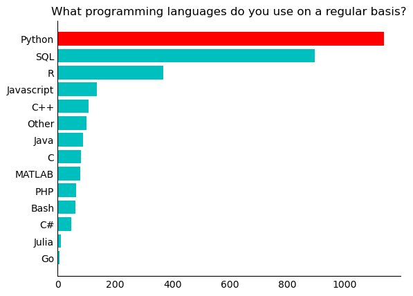

```python
from ks2022 import KaggleSurvey2022

csv_file = "kaggle_survey_2022_responses.csv"
ks = KaggleSurvey2022(csv_file)
ks.plot_survey_summary("Q12", n=1)
```

## Stack Overflow Trends

https://insights.stackoverflow.com/trends?tags=python%2Cr%2Cmatlab%2Cjulia%2Csas%2Cscala

## 關於 Python 的二三事

1. Python 的作者是荷蘭電腦科學家 Guido van Rossum
2. Python 的命名源於 Guido van Rossum 非常喜歡電視喜劇 Monty Python's Flying Circus
3. Python 的第一版釋出於 1991 年。

## 如何寫作與執行 Python 程式

## 寫作與執行 Python 程式需要三種類型的軟體

1. 純文字編輯器：寫作程式的軟體，例如記事本、Visual Studio Code 或 Notepad++。
2. 終端機：執行程式的軟體，例如 Windows 的命令提示字元、macOS 的 Terminal。
3. Python 直譯器：將 Python 程式翻譯為電腦語言的軟體。

## 我們將使用 Miniconda 搭配 Microsoft Visual Studio Code 寫作與執行 Python 程式

- [Miniconda](https://www.anaconda.com/docs/getting-started/miniconda/install#quickstart-install-instructions)：作為 Python 直譯器。
- [Microsoft Visual Studio Code](https://code.visualstudio.com/download)：作為純文字編輯器與終端機。
  - 安裝 VS Code Python extension 提升寫作效率。
  - 安裝 VS Code Markdown+Math extension 讓 VS Code 瀏覽練習題時可以顯示數學符號。

## 寫作與執行 Python 程式的兩種方式

1. 在 VS Code 寫作與執行（透過 VS Code Python extension）。
2. 在 VS Code 寫作、在 Anaconda Prompt/Powershell(Windows) 或 Terminal(macOS) 執行。

## 初登場的兩個 Python 程式

1. 哈囉世界。
2. Python 禪學（The Zen of Python）。

## 哈囉世界

- `print()` 是 Python 的內建函數，可以將小括號中的內容印出。
- `"Hello, world!"` 是屬於 `str` 類別的字面值（Literal value）。

```python
print("Hello, world!")
```

```
Hello, world!
```

## Python 禪學（The Zen of Python）

- `import` 是 Python 的保留字（Keywords），可以載入模組。
- `this` 是 Python 的一個標準模組，可以印出 Python 禪學。

```python
import this
```

```
The Zen of Python, by Tim Peters

Beautiful is better than ugly.
Explicit is better than implicit.
Simple is better than complex.
Complex is better than complicated.
Flat is better than nested.
Sparse is better than dense.
Readability counts.
Special cases aren't special enough to break the rules.
Although practicality beats purity.
Errors should never pass silently.
Unless explicitly silenced.
In the face of ambiguity, refuse the temptation to guess.
There should be one-- and preferably only one --obvious way to do it.
Although that way may not be obvious at first unless you're Dutch.
Now is better than never.
Although never is often better than *right* now.
If the implementation is hard to explain, it's a bad idea.
If the implementation is easy to explain, it may be a good idea.
Namespaces are one honking great idea -- let's do more of those!
```

## （沒什麼用的冷知識）Python 禪學在 `this` 模組中的內容是經過 ROT13 加密的文字

```
Gur Mra bs Clguba, ol Gvz Crgref

Ornhgvshy vf orggre guna htyl.
Rkcyvpvg vf orggre guna vzcyvpvg.
Fvzcyr vf orggre guna pbzcyrk.
Pbzcyrk vf orggre guna pbzcyvpngrq.
Syng vf orggre guna arfgrq.
Fcnefr vf orggre guna qrafr.
Ernqnovyvgl pbhagf.
Fcrpvny pnfrf nera'g fcrpvny rabhtu gb oernx gur ehyrf.
Nygubhtu cenpgvpnyvgl orngf chevgl.
Reebef fubhyq arire cnff fvyragyl.
Hayrff rkcyvpvgyl fvyraprq.
Va gur snpr bs nzovthvgl, ershfr gur grzcgngvba gb thrff.
Gurer fubhyq or bar-- naq cersrenoyl bayl bar --boivbhf jnl gb qb vg.
Nygubhtu gung jnl znl abg or boivbhf ng svefg hayrff lbh'er Qhgpu.
Abj vf orggre guna arire.
Nygubhtu arire vf bsgra orggre guna *evtug* abj.
Vs gur vzcyrzragngvba vf uneq gb rkcynva, vg'f n onq vqrn.
Vs gur vzcyrzragngvba vf rnfl gb rkcynva, vg znl or n tbbq vqrn.
Anzrfcnprf ner bar ubaxvat terng vqrn -- yrg'f qb zber bs gubfr!
```

## 重點統整

- 現代資料科學是以程式設計做資料分析的六個應用（Import/Tidy/Transform/Visualize/Model/Communicate）。
- 選擇 Python 作為資料分析應用的程式語言，因為這是目前最多人使用的程式語言。
- 初登場的兩個 Python 程式為哈囉世界與 Python 禪學（The Zen of Python）。